# Animint

Susan VanderPlas

Iowa State University

# Packages for Interactive and Animated Graphics

# [Animation](http://cran.r-project.org/web/packages/animation/index.html)

### Features

- Save graphics sequences using Flash, GIF, HTML, PDF, and videos
- Animate graphics from within R
- No user interaction with the graphic itself

### Software Considerations

- Does not require extra local software to run
- Graphics can be shared without an R installation

# [Rggobi](http://cran.r-project.org/web/packages/rggobi/index.html)

### Features

- User interaction: brushing, rotation, animation
- Linked plots
- Useful for exploratory visualization

### Software Considerations

- Requires ggobi graphics system (extra programs) with R on a user’s system
- Difficult to port interactive graphics to other computers that don’t have ggobi and R

# [Shiny](http://cran.r-project.org/web/packages/shiny/index.html)

### Features

- User interaction with some parameters:  
  plots will re-generate in response to user input
- Animated graphical sequences similar to those produced with the `animation` package

### Software Considerations

- Accessible via web or local machine with R
- Requires a server running R for hosting (or hosting app via [ShinyApps](http://my.shinyapps.io/]))

# [d3.js](http://d3js.org/)

### Features

- Animation
- Interactivity (selection, zoomable, mouseover)

### Software Considerations

- Web ready
- Knowledge of HTML and JavaScript required
- Low-level plotting language

# [ggvis](http://ggvis.rstudio.com/)

### Features

- Animation, zoomable plots, mouseover interaction
- Plots will change according to user input (similar to Shiny)

### Software Considerations

- Uses d3 and Vega (higher level interface to d3)
- Accessible via web or local machine with Rstudio
- Requires a server running R for hosting on the web

### Syntax is changing rapidly

# Animint

## d3 graphics in R with ggplot2 syntax

# [Animint](https://github.com/tdhock/animint)

- Created by Toby Hocking (McGill University)
- Development through Google Summer of Code

[figure not shown]

[figure not shown]

# Goal:

## Use ggplot2 syntax to create d3.js plots in R

#### Real goal: No one HAS to learn a new language to create interactive plots!

# Features

- Interactive (clickable), linked d3 plots
- Animation
- Familiar grammar-of-graphics syntax
- Use R to write the d3 code

# New Aesthetics

- **clickSelects** : changes the selected element in a plot
- **showSelected** : shows only data corresponding to the selected element
- **time**: animate the plot according to this variable
- **duration**: smooth transitions of these variables

# Code Comparison

## animint

```
geom_point(aes(x=fertility.rate, y=life.expectancy,
               clickSelects=country, showSelected=year,
               colour=region, size=population),
           data=WorldBank)
```

## d3

```
svg.selectAll("circle")
  .data(one_year)
  .enter().append("circle")
  .attr("cx", function(d){ return x_scale(d.fertility_rate); })
  .attr("cy", function(d){ return y_scale(d.life_expectancy); })
  .attr("r", function(d){ return size_scale(d.population); }
  .style("fill", function(d){ return color_scale(d.region); })
```

# Linked Plots with Animint

```r
library(animint)
data(WorldBank)

ts <- ggplot() + make_tallrect(WorldBank, "year")+
           geom_line(aes(year, life.expectancy, group=country,
                         colour=region, clickSelects=country),
                     data=WorldBank, size=4, alpha=3/5),
scatter <- ggplot() + make_text(WorldBank, 5, 80, "year") +
   geom_point(aes(life.expectancy, fertility.rate,
                  clickSelects=country, showSelected=year,
                  colour=region, size=population, key=country),
              # key aesthetic for animated transitions!
              data=WorldBank)+
   geom_text(aes(life.expectancy, fertility.rate,
                  label=country, showSelected=country,
                  showSelected2=year, key=country),
              #also use key here!
              data=WorldBank),
viz <- list(ts = ts, scatter = scatter,
            time = list(variable="year",ms=3000),
            duration = list(year=1000))
gg2animint(viz, open.browser=FALSE)
```

# Creating an animint plot

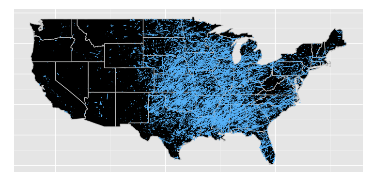

```r
USpolygons <- map_data("state")

map <- ggplot() +
  geom_polygon(aes(x=long, y=lat, group=group, clickSelects=state),
               data=USpolygons, fill="black", colour="grey") +
  geom_segment(aes(x=startLong, y=startLat, xend=endLong, yend=endLat,
                   showSelected=year),
               colour="#55B1F7", data=UStornadoes) +
  theme(axis.line=element_blank(), axis.text=element_blank(),
        axis.ticks=element_blank(), axis.title=element_blank()) +
  theme_animint(width=970, height=400) # plot dimensions
map
```

# Creating an animint plot

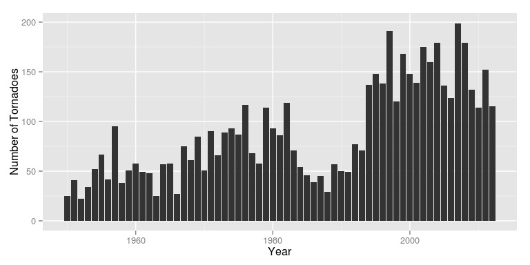

```r
ts <- ggplot() +
  geom_bar(aes(year, count, clickSelects=year, showSelected=state),
           data=UStornadoCounts, stat="identity", position="identity") +
  ylab("Number of Tornadoes") +
  xlab("Year") +
  theme_animint(width=500, height=400) # plot dimensions
ts
```

# Creating an animint plot

```r
tornado.bar <- list(map = map, ts = ts)

gg2animint(tornado.bar, out.dir = "tornado-bar", open.browser=FALSE)
```

# Adding dynamic plot labels

```r
UStornadoCounts <-
  ddply(UStornadoes, .(state, year), summarize, count=length(state))
# Count the number of tornadoes in each state, each year

map <- map + make_text(UStornadoCounts, x=-100, y=50,
                       label.var="year", format="Tornadoes in %d")

ts <- ts + make_text(UStornadoes, x=1980, y=200,
                     label.var="state")

tornado.bar <- list(map = map, ts = ts)
gg2animint(tornado.bar, out.dir = "tornado-bar2", open.browser=F)
```

# Animating with animint

```r
time <- list(variable="year", ms=1500)
  # new part of the list passed to gg2animint().

tornado.anim <- list(map=map, ts=ts, time=time)
# pass the time object in as another object in the main list.

gg2animint(tornado.anim, out.dir = "tornado-anim", open.browser=FALSE)
```

# ggplot2 Features

## Supported

- Most geoms (except dotplot, rug, smooth, boxplot, bin2d)  
  These can be made with other geoms that do work, plus summary functions
- Color, alpha, linetype, axis scales, area, size  
  Shape is not supported
- Some theme elements (removing axes, ticks, etc.)  
  Other theme elements can be set using custom css files

# Future work

- Shiny bindings to integrate animint into Shiny applets
- Custom selection bindings:  
  Set selected element aesthetics (color, alpha, size, fill, linetype) separately
- Improve data handling so that large data does not take prohibitively long to load
- Zoom/update axes in response to data subsetting
- Resize plots interactively
- Multiple selection
- Interactive legends
- Mouseover aesthetic to allow for more mouseover control

# Links

- [Animint Tutorial](https://tdhock.github.io/animint/index.html#intro)
- [Github page](https://github.com/tdhock/animint)
- [d3 graphics](http://bl.ocks.org/mbostock)
- [Today’s Slides](https://srvanderplas.github.io/Presentations/Animint/animint.html#/)